# FRE6971_FinalProject_DenizKural

### FRE 6971 - Fixed Income Quantitative Trading Final Project

Deniz Kural / dk3703

#### Data Preparation Part

Historical samples: \ 1/1/2010 through 1/1/2014, Estimation Sample (A) \ 1/1/2014 through 1/1/2016 Signal Building Sample (B) \ 1/1/2016 through 1/1/2018, Testing Sample (C)

```python
import numpy as np
import pandas as pd
import math
import statsmodels.api as sm
import matplotlib.pyplot as plt
import seaborn as sns
from scipy.optimize import least_squares, leastsq
from statsmodels.tsa.stattools import adfuller
from math import *
from hurst import compute_Hc
import warnings;
warnings.simplefilter('ignore')

%matplotlib inline
plt.style.use('seaborn')
```

```python
CM_ED=pd.read_csv("/Users/denizkuraal/Desktop/FRE6971_FinalProject/Constant_Maturity_ED.csv",index_col="Date",parse_dates=True)
```

```python
CM_ED.head()
```

| Date | ED1 | ED2 | ED3 | ED4 | ED5 | ED6 | ED7 | ED8 | ED9 | ED10 | ED11 | ED12 | ED13 | ED14 | ED15 | ED16 | ED17 | ED18 | ED19 | ED20 |
| --- | --- | --- | --- | --- | --- | --- | --- | --- | --- | --- | --- | --- | --- | --- | --- | --- | --- | --- | --- | --- |
| 2000-01-03 | 6.300146 | 6.579726 | 6.805882 | 7.018287 | 7.028155 | 7.119748 | 7.163734 | 7.230232 | 7.184041 | 7.195232 | 7.205515 | 7.265000 | 7.235150 | 7.259495 | 7.278118 | 7.358092 | 7.354708 | 7.396914 | 7.427265 | 7.506268 |
| 2000-01-04 | 6.275171 | 6.532367 | 6.763403 | 6.963487 | 6.973894 | 7.065366 | 7.109766 | 7.180379 | 7.133714 | 7.145372 | 7.155975 | 7.210109 | 7.180000 | 7.204755 | 7.223725 | 7.303605 | 7.299734 | 7.342448 | 7.372636 | 7.452906 |
| 2000-01-05 | 6.294548 | 6.582542 | 6.820957 | 7.014204 | 7.030129 | 7.126494 | 7.175916 | 7.250987 | 7.213686 | 7.225527 | 7.241706 | 7.300245 | 7.269865 | 7.295000 | 7.319284 | 7.404037 | 7.399817 | 7.442871 | 7.477671 | 7.564385 |
| 2000-01-06 | 6.292558 | 6.563636 | 6.792313 | 6.974441 | 6.990855 | 7.087533 | 7.142152 | 7.215723 | 7.173301 | 7.185680 | 7.202299 | 7.260325 | 7.229766 | 7.255227 | 7.275000 | 7.359521 | 7.354867 | 7.398412 | 7.433124 | 7.521096 |
| 2000-01-07 | 6.276060 | 6.525951 | 6.753566 | 6.918970 | 6.937110 | 7.032297 | 7.077964 | 7.156076 | 7.112993 | 7.125816 | 7.142907 | 7.200386 | 7.169677 | 7.195443 | 7.215701 | 7.300000 | 7.294925 | 7.338949 | 7.373583 | 7.462833 |

```python
CM_ED.columns=[str((i+1)*3)+"M" if (i+1)*3%12!=0  else (str(int((i+1)*3/12))+"Y") for i in range(20)]
```

### Plot Time Series of Eurodollar Rates

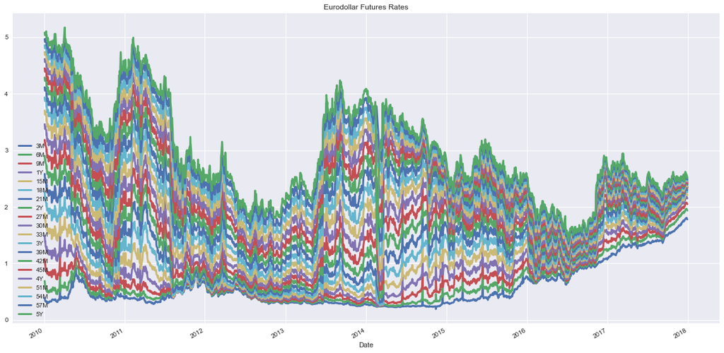

```python
CM_ED[(CM_ED.index >= '2010-1-1') & (CM_ED.index <= '2018-1-1')].plot(linewidth=3,figsize=(20,10), title = 'Eurodollar Futures Rates')
```

```python
CM_ED.head()
```

| Date | 3M | 6M | 9M | 1Y | 15M | 18M | 21M | 2Y | 27M | 30M | 33M | 3Y | 39M | 42M | 45M | 4Y | 51M | 54M | 57M | 5Y |
| --- | --- | --- | --- | --- | --- | --- | --- | --- | --- | --- | --- | --- | --- | --- | --- | --- | --- | --- | --- | --- |
| 2000-01-03 | 6.300146 | 6.579726 | 6.805882 | 7.018287 | 7.028155 | 7.119748 | 7.163734 | 7.230232 | 7.184041 | 7.195232 | 7.205515 | 7.265000 | 7.235150 | 7.259495 | 7.278118 | 7.358092 | 7.354708 | 7.396914 | 7.427265 | 7.506268 |
| 2000-01-04 | 6.275171 | 6.532367 | 6.763403 | 6.963487 | 6.973894 | 7.065366 | 7.109766 | 7.180379 | 7.133714 | 7.145372 | 7.155975 | 7.210109 | 7.180000 | 7.204755 | 7.223725 | 7.303605 | 7.299734 | 7.342448 | 7.372636 | 7.452906 |
| 2000-01-05 | 6.294548 | 6.582542 | 6.820957 | 7.014204 | 7.030129 | 7.126494 | 7.175916 | 7.250987 | 7.213686 | 7.225527 | 7.241706 | 7.300245 | 7.269865 | 7.295000 | 7.319284 | 7.404037 | 7.399817 | 7.442871 | 7.477671 | 7.564385 |
| 2000-01-06 | 6.292558 | 6.563636 | 6.792313 | 6.974441 | 6.990855 | 7.087533 | 7.142152 | 7.215723 | 7.173301 | 7.185680 | 7.202299 | 7.260325 | 7.229766 | 7.255227 | 7.275000 | 7.359521 | 7.354867 | 7.398412 | 7.433124 | 7.521096 |
| 2000-01-07 | 6.276060 | 6.525951 | 6.753566 | 6.918970 | 6.937110 | 7.032297 | 7.077964 | 7.156076 | 7.112993 | 7.125816 | 7.142907 | 7.200386 | 7.169677 | 7.195443 | 7.215701 | 7.300000 | 7.294925 | 7.338949 | 7.373583 | 7.462833 |

```python
# 1/1/2010 through 1/1/2014, Estimation Sample (A)
sample_A = CM_ED[(CM_ED.index >= '2010-1-1') & (CM_ED.index <= '2014-1-1')]
#1/1/2014 through 1/1/2016 Signal Building Sample (B)
sample_B = CM_ED[(CM_ED.index >= '2014-1-1') & (CM_ED.index <= '2016-1-1')]
#1/1/2016 through 1/1/2018, Testing Sample (C)
sample_C = CM_ED[(CM_ED.index >= '2016-1-1') & (CM_ED.index <= '2018-1-1')]
```

#### Co-integration Part

Use Sample A to compute cointegrated butterflies of ED futures rates: [2y,3y,5y], [3y,4y,5y], [2y,3y,4y], [2y,4y,5y]. Weight on the belly of a butterlfy is 1 for all combinations.

```python
#CCA for cointegration Analysis with utilization of Chou-Ng Method
def CCA_Chou_Ng(data_set):

    #data_set is pandas dataframe

    #define df_lag as the 1-period lag of data_set
    df_lag = data_set.shift(1).dropna()

    #drop the 0-index of data_set to make sure df and df_lag are aligned
    df = data_set.drop(data_set.index[0]).dropna()
    n = len(data_set.columns)

    #X(t) ~ M_1 + X(t-1)

    # input variables
    X = df_lag.values

    # ensures there is an intercept
    X_I = sm.add_constant(X)

    # regression target
    Y = df.values

    # fit regression
    l1 = sm.OLS(Y,X_I).fit()

    # get the coefficients/betas without the intercept
    B=l1.params[1:(n+1)]

    #X(t-1) ~ M_2 + X(t)

    # regression, reversing the dependent and the independent
    Y_I = sm.add_constant(Y)
    l2 = sm.OLS(X,Y_I).fit()

    # get the coefficients/betas without the intercept
    A=l2.params[1:(n+1)]

    # take the dot product of the two coefficient matrices
    C = np.dot(A,B)
    eig_val, eig_vec = np.linalg.eig(C)
    return eig_val, eig_vec, C
```

#### Function for cointegrated butterfly weight computation

```python
#Function CCA_ED
#data_set: input data set for CCA Calculation
#belly weight: choose of belly weight in butetrfly spread (For this project, belly_weight=1)

def CCA_ED(data_set,belly_weight):
    val, vec, C = CCA_Chou_Ng(data_set)
    w=vec[:,val.argmin()]
    w_cca_cn = [w[0]/w[1]*belly_weight,w[2]/w[1]*belly_weight]
    weights=np.array([w_cca_cn[0],belly_weight,w_cca_cn[1]])
    butterfly= weights[0]*data_set.iloc[:,0]+weights[1]*data_set.iloc[:,1]+weights[2]*data_set.iloc[:,2]
    return weights,butterfly
```

#### Cointegrated butterflies of ED futures rates: [2y,3y,5y]

```
Weights for cointegrated butterfly of [2y,3y,5y] is [-0.70732736  1.         -0.45026079]
```

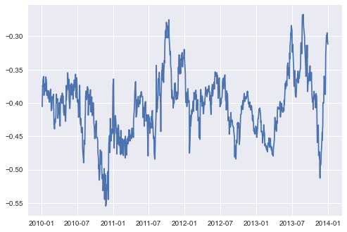

```python
weight1,series1 = CCA_ED(sample_A.loc[:,['2Y','3Y','5Y']],belly_weight=1.0)
print('Weights for cointegrated butterfly of [2y,3y,5y] is',weight1)
plt.plot(series1.index,series1)
plt.show()
```

#### Cointegrated butterflies of ED futures rates: [3y,4y,5y]

```
Weights for cointegrated butterfly of [3y,4y,5y] is [-0.42187028  1.         -0.61488269]
```

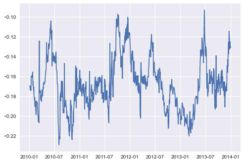

```python
weight2,series2= CCA_ED(sample_A.loc[:,['3Y','4Y','5Y']],belly_weight=1.0)
print('Weights for cointegrated butterfly of [3y,4y,5y] is',weight2)
plt.plot(series2.index,series2)
plt.show()
```

#### Cointegrated butterflies of ED futures rates: [2y,3y,4y]

```
Weights for cointegrated butterfly of [2y,3y,4y] is [-0.54128324  1.         -0.55886986]
```

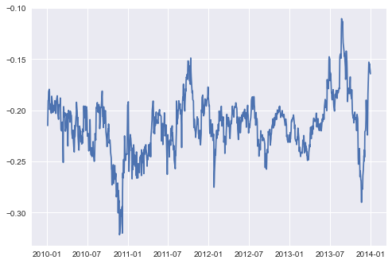

```python
weight3,series3= CCA_ED(sample_A.loc[:,['2Y','3Y','4Y']],belly_weight=1.0)
print('Weights for cointegrated butterfly of [2y,3y,4y] is',weight3)
plt.plot(series3.index,series3)
plt.show()
```

#### Cointegrated butterflies of ED futures rates: [2y,4y,5y]

```
Weights for cointegrated butterfly of [2y,4y,5y] is [-0.28447303  1.         -0.81316743]
```

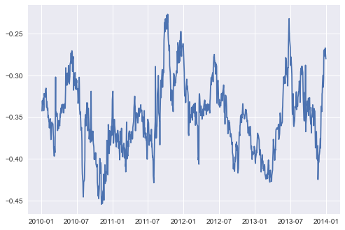

```python
weight4,series4= CCA_ED(sample_A.loc[:,['2Y','4Y','5Y']],belly_weight=1.0)
print('Weights for cointegrated butterfly of [2y,4y,5y] is',weight4)
plt.plot(series4.index,series4)
plt.show()
```

#### Let's define z(t,$\lambda$ ) as {x(t) - EMA(x(t);$\lambda$ )} where x(t) is a cointegrated butterfly at t. Use Sample B to construct the following forecasting models:

```python
#Forecast for AR(1) Process for each time (t)
def forecast(length,intercept,slope,data):
    data_x=data
    for i in range(length):
        data_x = intercept + slope * data_x
    return data_x

#AR(1) process for given function z(t,lambda) which includes EMA, and considering 6 month rolling window
def AR1_EMA(data_set,alph_a,length):
    df_predict = pd.Series(index = data_set.index)
    df_all = pd.DataFrame(index = data_set.index, columns = ['realized','predicted'])
    df_all.iloc[:,0] = data_set[120:len(data_set.index)]

    if alph_a == 0:
        for ind in range(120,len(data_set.index)-length):
            AR1_6m = data_set.iloc[(ind-120):(ind)]
            #print(EMA_6m)
            x = AR1_6m.shift(1).dropna() # Y(t-1)
            y = AR1_6m.drop(AR1_6m.index[0]) # Y(t) - Y(t-1)
            x = sm.add_constant(x) #adds intercept terms to X variable for regression
            intercept,slope = sm.OLS(y,x).fit().params
            df_predict[ind+length]=forecast(length,intercept,slope,data_set[ind])
        df_all.iloc[:,1] = df_predict


    else:
        for ind in range(120,len(data_set.index)-length):
            AR1_6m = data_set.iloc[(ind-120):(ind)]
            EMA_6m= data_set.iloc[(ind-120):(ind)].ewm(alpha=alph_a).mean()
            AR1_6m= AR1_6m-EMA_6m
            #print(EMA_6m)
            x = AR1_6m.shift(1).dropna() # Y(t-1)
            y = AR1_6m.drop(AR1_6m.index[0]) # Y(t)
            x = sm.add_constant(x) #X - Intercept term
            intercept,slope = sm.OLS(y,x).fit().params
            df_predict[ind+length]=forecast(length,intercept,slope,data_set[ind])


        EMA= data_set.iloc[(120):len(data_set.index)-length].ewm(alpha=alph_a).mean()
        df_all.iloc[:,1] = df_predict + EMA

    df_all=df_all.dropna()


    return df_all
```

### Signal 1

a. AR(1) model fitted to z(t,$\lambda$ = 0) (Signal 1), this is a constant mean

```python
b1=weight1[0]*sample_B.loc[:,'2Y']+weight1[1]*sample_B.loc[:,'3Y']+weight1[2]*sample_B.loc[:,'5Y']
b2=weight2[0]*sample_B.loc[:,'3Y']+weight2[1]*sample_B.loc[:,'4Y']+weight2[2]*sample_B.loc[:,'5Y']
b3=weight3[0]*sample_B.loc[:,'2Y']+weight3[1]*sample_B.loc[:,'3Y']+weight3[2]*sample_B.loc[:,'4Y']
b4=weight4[0]*sample_B.loc[:,'2Y']+weight4[1]*sample_B.loc[:,'4Y']+weight4[2]*sample_B.loc[:,'5Y']
```

```python
#Signal 1

#Each signal is named with respect to its butterfly spread ( This will be the case for all signals)
s1_2y3y5y=AR1_EMA(b1,0,10)
s1_3y4y5y=AR1_EMA(b2,0,10)
s1_2y3y4y=AR1_EMA(b3,0,10)
s1_2y4y5y=AR1_EMA(b4,0,10)
```

#### Plot for Signals

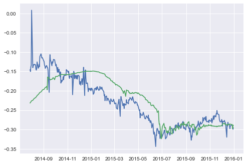

```python
plt.plot(s1_2y3y5y)
plt.show()
```

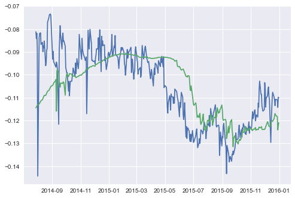

```python
plt.plot(s1_3y4y5y)
plt.show()
```

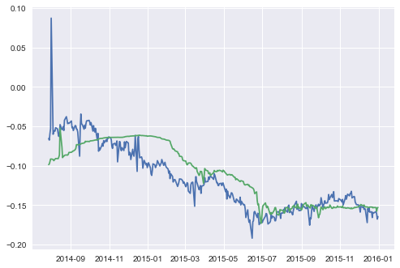

```python
plt.plot(s1_2y3y4y)
plt.show()
```

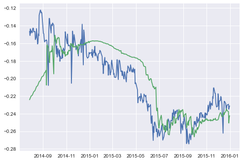

```python
plt.plot(s1_2y4y5y)
plt.show()
```

### Signal 2

b. AR(1) model fitted to z(t,$\lambda$ = 0.05) (Signal 2)

```python
#Signal 2

s2_2y3y5y=AR1_EMA(b1,0.05,10)
s2_3y4y5y=AR1_EMA(b2,0.05,10)
s2_2y3y4y=AR1_EMA(b3,0.05,10)
s2_2y4y5y=AR1_EMA(b4,0.05,10)
```

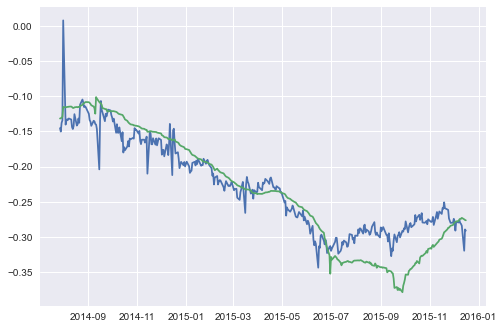

```python
plt.plot(s2_2y3y5y)
plt.show()
```

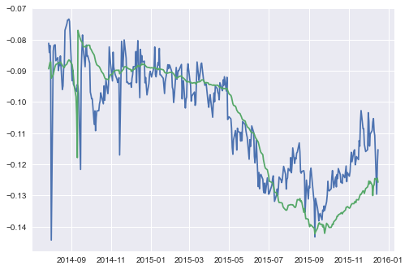

```python
plt.plot(s2_3y4y5y)
plt.show()
```

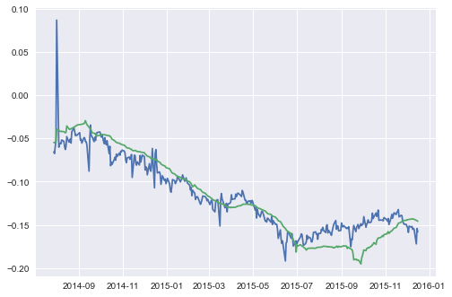

```python
plt.plot(s2_2y3y4y)
plt.show()
```

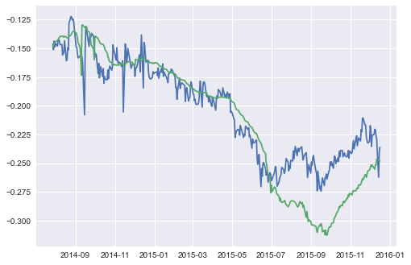

```python
plt.plot(s2_2y4y5y)
plt.show()
```

### Signal 3

c. AR(1) model fitted to z(t,$\lambda$ = 0.1) (Signal 3)

```python
#Signal 3

s3_2y3y5y=AR1_EMA(b1,0.1,10)
s3_3y4y5y=AR1_EMA(b2,0.1,10)
s3_2y3y4y=AR1_EMA(b3,0.1,10)
s3_2y4y5y=AR1_EMA(b4,0.1,10)
```

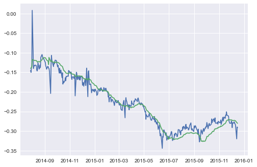

```python
plt.plot(s3_2y3y5y)
plt.show()
```

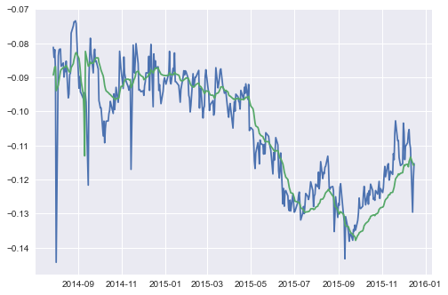

```python
plt.plot(s3_3y4y5y)
plt.show()
```

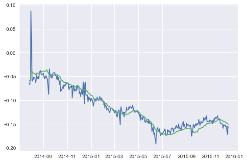

```python
plt.plot(s3_2y3y4y)
plt.show()
```

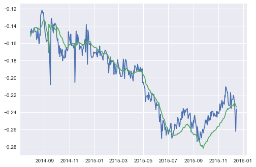

```python
plt.plot(s3_2y4y5y)
plt.show()
```

### Signal 4 Computation with Optimizer

Searchs for optimal weigths in Signal 4 computation in the range of [0,1] for all weights. \ Signal 4 formula is given below: \ Signal 4= Signal 1 x optimized_weight1 +Signal 2 x optimized_weight2+Signal 3 x optimized_weight3

```python
#optimizer Function

class optimizer:

    #Initial value for lambda vector = [0.,0.,0.]
    def __init__(self,lamda,data_set_1):
        self.lamda = lamda
        self.data_set_1 = data_set_1
        data_set_2= AR1_EMA(self.data_set_1,0,10)
        self.s1 = data_set_2.predicted
        self.s2 = AR1_EMA(self.data_set_1,0.05,10).predicted
        self.s3 = AR1_EMA(self.data_set_1,0.1,10).predicted
        self.s4 = pd.DataFrame(index = data_set_2.index, columns = ['realized','predicted'])
        self.s4.realized=data_set_2.realized[:-10]
    # Finding RMSE Residuals wrt. each lambda
    def residuals(self,lamda):
        #print("lambda:",lamda)
        self.s4.predicted= (lamda[0]*self.s1.add(lamda[1]*self.s2,fill_value=0)).add(lamda[2]*self.s3,fill_value=0)[:-10].dropna()
        #s4.predicted=lamda[0]*self.s1+lamda[1]*self.s2+lamda[2]*self.s3
        rmse = np.sqrt(((self.s4.predicted - self.s4.realized) ** 2).mean())
        #print("RMSE:",rmse)
        #print()
        return rmse

    # Model fit with least-squares method
    def fit(self,lamda0):
        return least_squares(self.residuals,lamda0,bounds=([0, 0,0], [1, 1,1]))
```

```python
#Initial value for lambda vector = [0.5,0.5,0.5]
lamda0=[0.5,0.5,0.5]
#For butterfly 1:
optim_model_b1 = optimizer(lamda0,b1)
optim_b1 = optim_model_b1.fit(lamda0)
#For butterfly 2:
optim_model_b2 = optimizer(lamda0,b2)
optim_b2 = optim_model_b2.fit(lamda0)
#For butterfly 3:
optim_model_b3 = optimizer(lamda0,b3)
optim_b3 = optim_model_b3.fit(lamda0)
#For butterfly 4:
optim_model_b4 = optimizer(lamda0,b4)
optim_b4 = optim_model_b4.fit(lamda0)
```

```python
print("The value for optimal \u03BB of [2y,3y,5y]  is " ,optim_b1.x)
print("The cost of the optimal \u03BB solution  is %.4f" %optim_b1.cost)

print("The value for optimal \u03BB of [3y,4y,5y] is " ,optim_b2.x)
print("The cost of the optimal \u03BB solution  is %.4f" %optim_b2.cost)

print("The value for optimal \u03BB of [2y,3y,4y] is  " ,optim_b3.x)
print("The cost of the optimal \u03BB solution  is %.4f" %optim_b3.cost)

print("The value for optimal \u03BB of [2y,4y,5y] is " ,optim_b4.x)
print("The cost of the optimal \u03BB solution  is %.4f" %optim_b4.cost)
```

```
The value for optimal λ of [2y,3y,5y]  is  [0.03629842 0.35517075 0.94132648]
The cost of the optimal λ solution  is 0.0001
The value for optimal λ of [3y,4y,5y] is  [0.18740846 0.46092356 0.72011016]
The cost of the optimal λ solution  is 0.0000
The value for optimal λ of [2y,3y,4y] is   [4.79732633e-04 3.28779076e-01 9.91519049e-01]
The cost of the optimal λ solution  is 0.0001
The value for optimal λ of [2y,4y,5y] is  [0.09646851 0.39845172 0.85046908]
The cost of the optimal λ solution  is 0.0001
```

##### Signal 4 Results and Equation

Signal 4= Signal 1 x optimized_weight1 +Signal 2 x optimized_weight2+Signal 3 x optimized_weight3

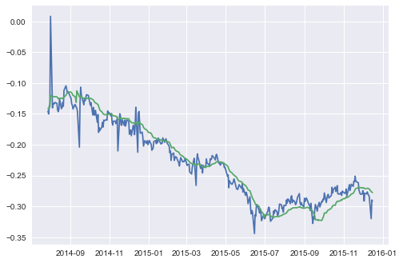

```python
s4_b1 = optimizer(optim_b1.x,b1)
predict=s4_b1.residuals(optim_b1.x)
plt.plot(s4_b1.s4)
```

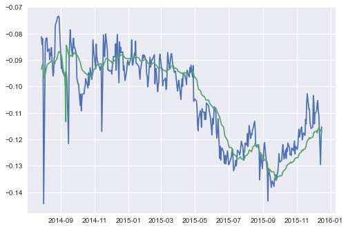

```python
s4_b2 = optimizer(optim_b2.x,b2)
predict=s4_b2.residuals(optim_b2.x)
plt.plot(s4_b2.s4)
```

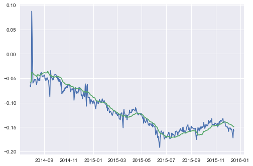

```python
s4_b3 = optimizer(optim_b3.x,b3)
predict=s4_b3.residuals(optim_b3.x)
plt.plot(s4_b3.s4)
```

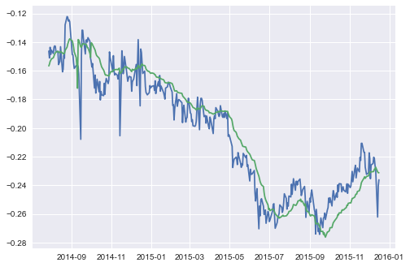

```python
s4_b4 = optimizer(optim_b4.x,b4)
predict=s4_b4.residuals(optim_b4.x)
plt.plot(s4_b4.s4)
```

## Results $\&$ Discussion

#### Define a set of signal quality metrics, and explain clearly what you are implementing.

### Define Metrics for Signal Quality

```python
#RMSE Test for evaluating error in forecast
def RMSE(data_set):
    rmse = np.sqrt(((data_set.iloc[:,0] - data_set.iloc[:,1]) ** 2).mean())
    print("RMSE:",rmse)
    #return rmse
```

```python
#Mean-Reversion Tests
#we will consider these tests for to see if generated and real signals show similar mean reverting properties.

#Augmented Dickey-Fuller Test
def ADF(data_set):
    result = adfuller(data_set,autolag='AIC')
    print('ADF Statistic: %f' % result[0])
    print('p-value: %f' % result[1])
    print('Critical Values:')
    for key, value in result[4].items():
        print('\t%s: %.3f' % (key, value))
    #return result

#Half-life of Mean Reversion
def half_life(data_set):
    price = pd.Series(data_set)
    lagged_price = price.shift(1).fillna(method="bfill")
    delta = price - lagged_price
    beta = np.polyfit(lagged_price, delta, 1)[0] #Use price(t-1) to predicate delta.
    half_life = (-1*log(2)/beta)
    print("Half-Life:",half_life)
    print("Beta:",beta)
    #return(half_life,beta)

#Hurst Exponent Test
def Hurst_exponent(data_set):
    #Result includes Hurst exponent (H) and the constant (c) and val.
    # Result: [H,c, val]
    result = compute_Hc(data_set)
    print("Hurst Exponent:",result[0])
    #return result
```

#### Distribution plot depicts the variation in the data distribution.

```python
def dist_plotv2(df1,df2,df3,df4):
    # Set up the matplotlib figure
    f, axes = plt.subplots(2, 2, figsize=(7, 7), sharex=True)
    sns.despine(left=True)

    sns.distplot(df1.predicted ,kde=False,axlabel="Range",ax=axes[0, 0])
    sns.distplot(df1.realized ,kde=False,axlabel="Range",ax=axes[0, 0])
    sns.distplot(df2.predicted ,kde=False,axlabel="Range",ax=axes[0, 1])
    sns.distplot(df2.realized ,kde=False,axlabel="Range",ax=axes[0, 1])
    sns.distplot(df3.predicted ,kde=False,axlabel="Range",ax=axes[1, 0])
    sns.distplot(df3.realized ,kde=False,axlabel="Range",ax=axes[1, 0])
    sns.distplot(df4.predicted ,kde=False,axlabel="Range",ax=axes[1, 1])
    sns.distplot(df4.realized ,kde=False,axlabel="Range",ax=axes[1, 1])
    plt.setp(axes, yticks=[])
    plt.tight_layout()
```

Firstly, start with observing training test and its properties for found cointegrated butterflies of ED futures rates. So, we can evaluate results for sample B ( Validation set ) and sample C (Test set) better.

## Sample (A) Evaluation

```python
# Butterfly 1: [2y,3y,5y]
print("Results for Butterfly 1: [2y,3y,5y] ")
half_life(series1)
print()
ADF(series1)
print()
Hurst_exponent(series1)
```

```
Results for Butterfly 1: [2y,3y,5y]
Half-Life: 18.279425454510736
Beta: -0.03791952773815986

ADF Statistic: -3.772861
p-value: 0.003198
Critical Values:
	1%: -3.437
	5%: -2.864
	10%: -2.568

Hurst Exponent: 0.37463621365145
```

```python
# Butterfly 2: [2y,3y,5y]
print("Results for Butterfly 2: [3y,4y,5y] ")
half_life(series2)
print()
ADF(series2)
print()
Hurst_exponent(series2)
```

```
Results for Butterfly 2: [3y,4y,5y]
Half-Life: 12.917910542235285
Beta: -0.053657840274840975

ADF Statistic: -3.808347
p-value: 0.002823
Critical Values:
	1%: -3.437
	5%: -2.864
	10%: -2.568

Hurst Exponent: 0.32712490762968083
```

```python
# Butterfly 3: [2y,3y,4y]
print("Results for Butterfly 3: [3y,4y,5y] ")
half_life(series3)
print()
ADF(series3)
print()
Hurst_exponent(series3)
```

```
Results for Butterfly 3: [3y,4y,5y]
Half-Life: 13.77884817533688
Beta: -0.0503051613414703

ADF Statistic: -4.113069
p-value: 0.000921
Critical Values:
	1%: -3.437
	5%: -2.864
	10%: -2.568

Hurst Exponent: 0.38116342029343503
```

```python
# Butterfly 3: [2y,3y,4y]
print("Results for Butterfly 4: [2y,4y,5y] ")
half_life(series4)
print()
ADF(series4)
print()
Hurst_exponent(series4)
```

```
Results for Butterfly 4: [2y,4y,5y]
Half-Life: 17.007132035586192
Beta: -0.040756265025142686

ADF Statistic: -3.725775
p-value: 0.003765
Critical Values:
	1%: -3.437
	5%: -2.864
	10%: -2.568

Hurst Exponent: 0.3557355986637039
```

As we can observe from above results, sample A shows stationarity or sample A behaves as mean reverting process. This can be understood from the metrics found above for all cointegrated butterflies. Beta in half-life formula indicates stationarity if it is negative which was a case for all combinations. Moreover, ADF statistic for all of the combanitons shows that null hypothesis can be rejected with 99% confidence(showing stationarity).Lastly, as Hurst exponent is less than 0.5, the combinations of time series data indicates mean reverting process.